# Analysis on Car Prices through Correlation with `corrplot`

### Shade

[figure not shown]

```r
corrplot(GPAcorr, method = 'shade')
```

Analysis: With the shade methods, the visualization is pretty similar. The color representation is same with red symbolizing a negative correlation and blue symbolizing a positive correlation. However, the size of the square is all the same. A negative correlation is represented with a white-diagonal lines within the square. A positive correlation is represented with a solid square.

### Pie

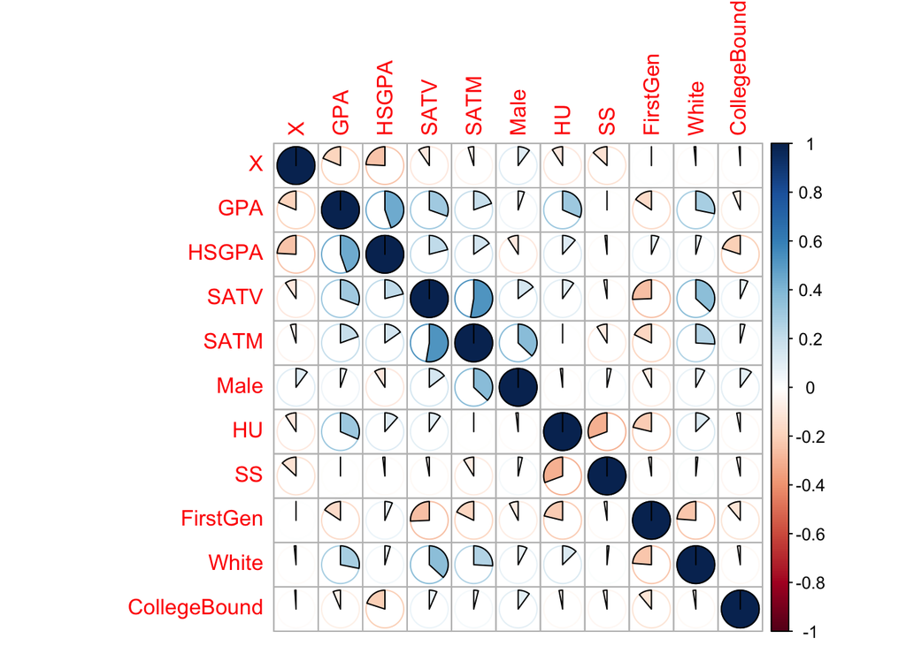

```r
corrplot(GPAcorr, method = 'pie')
```

Analysis: As previously mentioned before, the color of the pie and color spectrum represent the correlation of the variables. The proportion of each pie shows the magnitude of the correlation.

### Number

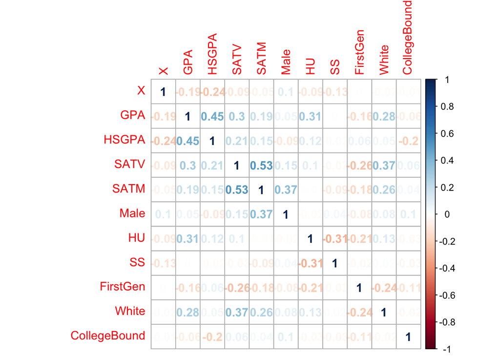

```r
corrplot(GPAcorr, method = 'number')
```

Analysis: Corrplot also allows us to use number to represent the correlation with color. Together, the numbers and shade of color represent the specific correlation of the variables.

## 2. Layout

In `corrplot`, there are three different layouts: full, upper, and lower. The default layout that have been used in the previous correlation have all been “full”. In this section, I’ll show the other types of layouts.

### Upper

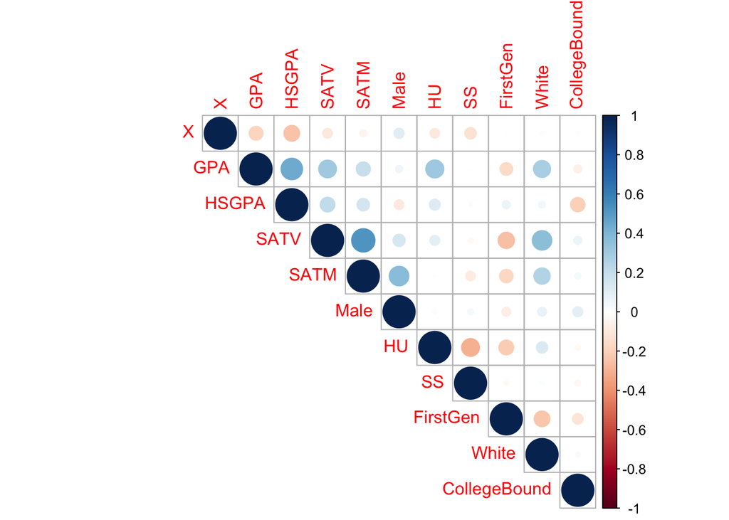

```r
corrplot(GPAcorr, type = 'upper')
```

Analysis: The upper layout shows the upper triangle of the correlation matrix.

### Lower

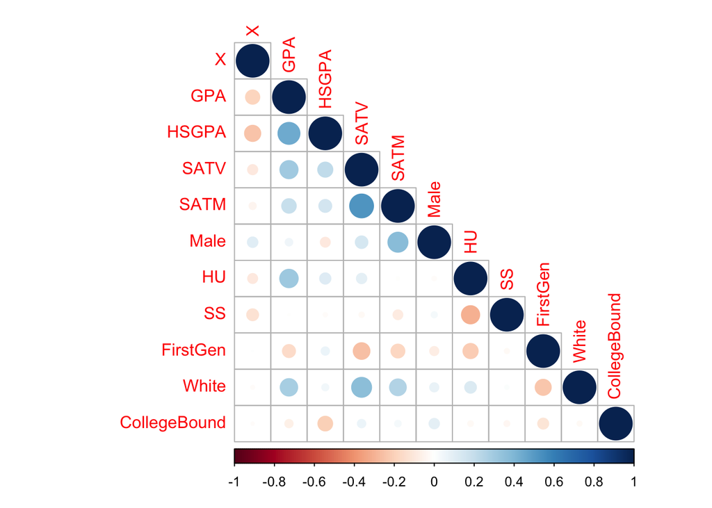

```r
corrplot(GPAcorr, type = 'lower')
```

Analysis: The lower layout shows the lower triangle of the correlation matrix. If you have noticed, the full is the combination of both the upper and lower layout. Layout is just for the user’s preference.

### Mixed

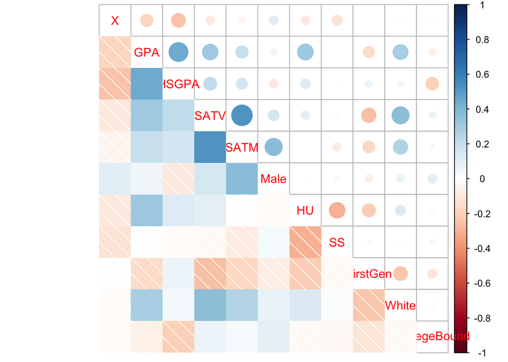

```r
corrplot.mixed(GPAcorr, lower = 'shade', upper = 'circle')
```

Analysis: With the function `corrplot.mixed`, we are able to combind two different methods separated by the upper and lower. The variables are labeled diagonally in the graph. It is nice to display data in different ways.

## 3. Reorder

Although the graph is a huge improvement in interpreting correlation data, the correlation matrix can be reordered by the correlation coefficient. There are four method in `corrplot`: AOE, FPC, hclust, and alphabet.

### AOE

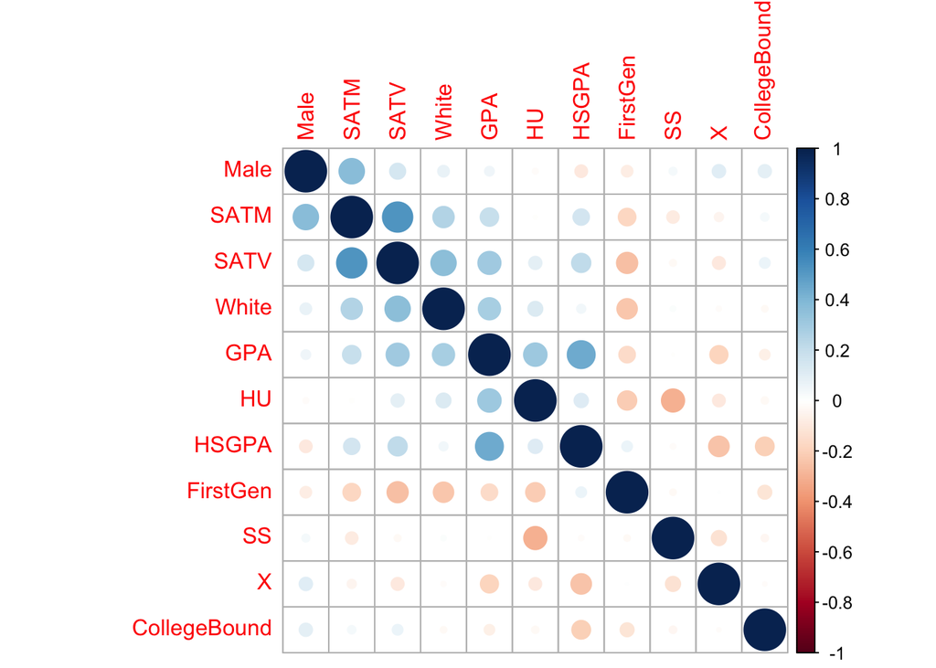

```r
corrplot(GPAcorr, order = "AOE")
```

Analysis: AOE order the matrix through the argular order of eigenvector. All the positive correlation are group in the upper left corner. The higher the magnitude, the closer the points are to the middle diagonal.

### hclust

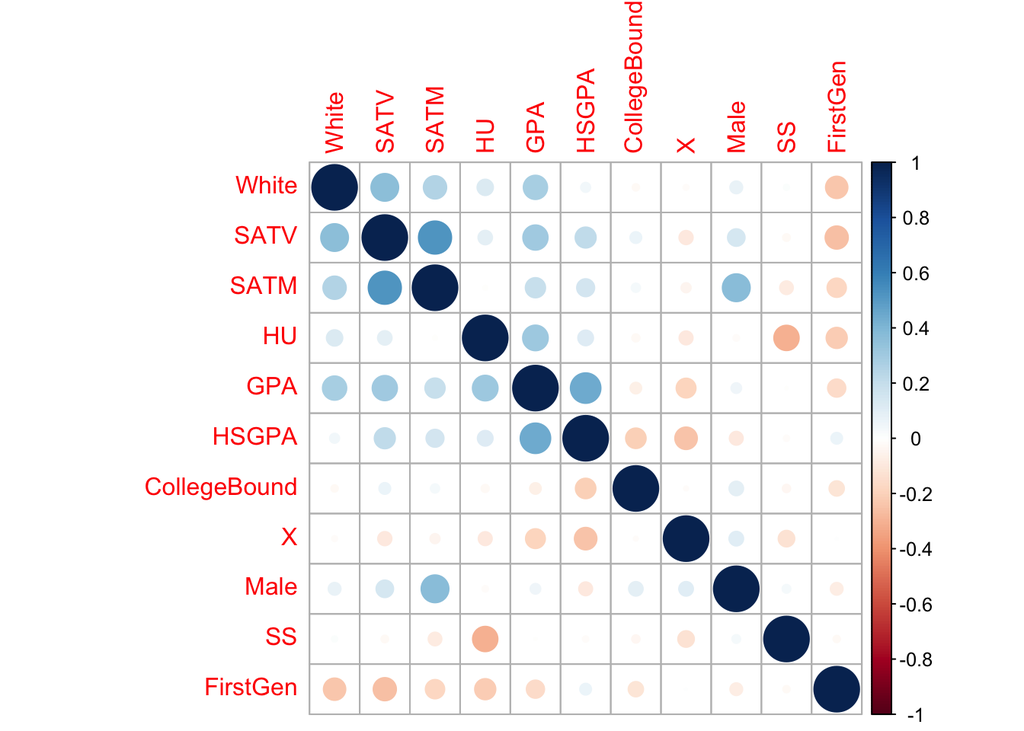

```r
corrplot(GPAcorr, order = 'hclust')
```

Analysis: `hclust` stands for heirarachial lustering order. The function performs a “hierarchicial luster analysis”, which uses dissimilarities sets of the variables. Again in this order, the positive correlated points are aggregate in the top. For example, we can see that ‘White’ and ‘SAT scores’ has a positive correlation with GPA.